# FigureYa105GDSC

小丫画图出品

2019-6-20

欢迎关注“小丫画图”公众号，同名知识星球等你加入

小丫微信: epigenomics E-mail: figureya@126.com

作者：大鱼海棠

单位：Research Center of Biostatistics and Computational Pharmacy, China Pharmaceutical University

小丫编辑校验

## 需求描述

利用pRRophetic算法，根据GDSC<www.cancerrxgene.org/>细胞系表达谱和TCGA基因表达谱构建岭回归模型预测药物IC50（使用原文数据，复现原图）

提示：pRRophetic的示例可参考：https://github.com/paulgeeleher/pRRophetic/blob/master/vignetteOutline.pdf

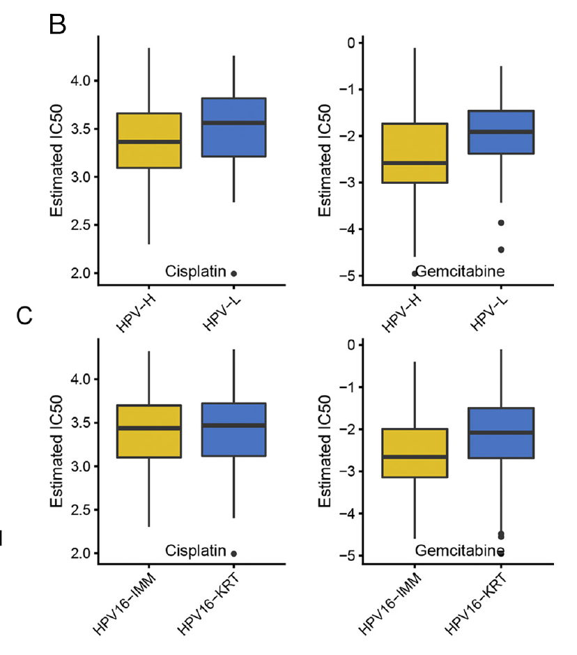

出自https://www.sciencedirect.com/science/article/pii/S1476558619301307

**注意：**由于包含原文数据，若涉及到注释文件亚型及其他相关数据的使用，请引用： Lu X, Jiang L, Zhang L, et al. Immune Signature-Based Subtypes of Cervical Squamous Cell Carcinoma Tightly Associated with Human Papillomavirus Type 16 Expression, Molecular Features, and Clinical Outcome[J]. Neoplasia, 2019, 21(6): 591-601.

## 应用场景

预测病人对药物的IC50，画box plot图对比不同分组。

还可以通过批量计算，筛选出组间差异显著的药物。

## 环境设置

使用国内镜像安装包

```r
options("repos"= c(CRAN="https://mirrors.tuna.tsinghua.edu.cn/CRAN/"))
options(BioC_mirror="http://mirrors.ustc.edu.cn/bioc/")
BiocManager::install(c("car", "ridge", "preprocessCore", "genefilter", "sva"))
```

GDSC数据库里的内容可以用R包pRRophetic来访问和计算。

点击链接下载pRRophetic_0.5.tar.gz：https://osf.io/dwzce/?action=download，然后本地安装。

加载包

```r
library(pRRophetic)
```

```r
library(ggplot2)
library(cowplot)
Sys.setenv(LANGUAGE = "en") #显示英文报错信息
options(stringsAsFactors = FALSE) #禁止chr转成factor
```

## 输入文件

需要三个文件：表达数据、分组信息和药物名字，前两个文件的sample ID必须一致。

easy_input_expr.txt，基因表达矩阵。

easy_input_anno.txt，分组信息。示例数据里的C1和C2分别对应“HPV16-IMM”和“HPV16-KRT”。也可以是按某个基因的突变类型分组、或按某个基因表达量高低分组。

drug.txt，要计算和画图的药物的名字，药物名必须存在与GDSC数据库中。**具体选哪个药物呢？**可以基于背景知识来选择合适的药物，就像例文那样；也可以批量筛选组间差异显著的药物做深入研究。

getCGPinfo函数内部是2016版药物的名字，共251种；GDSC数据库的网站上2019版的药物名字有266种：https://www.cancerrxgene.org/translation/Drug#t-all；然而pRRopheticPredict函数的drug参数the name of the drug for which you would like to predict sensitivity, one of…，其中的药物名字只有138个，下面就对这138种药物进行计算和画图。把pRRopheticPredict函数的drug参数中的药物整理后保存在drug.txt文件中。

```r
#表达矩阵
dat <- read.table("easy_input_expr.txt",sep = "\t",row.names = 1,header = T,stringsAsFactors = F,check.names = F)
dat[1:3, 1:3]
```

```
##        CESC-A0TN-01A CESC-A0VK-01A CESC-A0VL-01A
## TSPAN6          11.9          12.1          12.3
## TNMD             0.0           0.0           1.3
## DPM1            11.3          11.3          11.2
```

```r
#分组信息
ann <- read.table("easy_input_anno.txt",sep = "\t",row.names = 1,header = T,stringsAsFactors = F,check.names = F)
head(ann)
```

```
##               ImmClust
## CESC-A0TN-01A       C2
## CESC-A0VK-01A       C2
## CESC-A0VL-01A       C1
## CESC-A0VM-01A       C2
## CESC-A0VN-01A       C1
## CESC-A0VR-01A       C1
```

```r
table(ann$ImmClust)
```

```
##
## C1 C2
## 53 85
```

```r
#药物名字
GCP.drug <- read.table("drug.txt") #如果要例文的两种药物，就换成drug_eg.txt
GCP.drug <- GCP.drug$V1
#这里以前12种药物为例
GCP.drug <- GCP.drug[1:12]
```

## 药物敏感性预测和画图

```r
# 自定义足够多的box的颜色，颜色数量至少等于分组数量
jco <- c("#EABF00", "#2874C5", "red")

### 药物敏感性预测 ###、
GCPinfo <- GCP.IC50 <- GCP.expr <- cvOut <- predictedPtype <- predictedBoxdat <- list() # 初始化列表
plotp <- list()

for (drug in GCP.drug) {
  set.seed(1248103) # 因为预测过程默认10-fold CV，所以设置种子以便结果可重复
  cat(drug," starts!\n") # 提示当前药物已开始分析

  # 预测IC50值，采用默认参数，详细可参考??pRRopheticPredict参数列表
  predictedPtype[[drug]] <- pRRopheticPredict(testMatrix = as.matrix(dat[,rownames(ann)]),
                                              drug = drug,
                                              tissueType = "allSolidTumors",
                                              selection = 1) # 1表示若有重复基因取均值处理

  if(!all(names(predictedPtype[[drug]])==rownames(ann))) {stop("Name mismatched!\n")} # 若名字不匹配则报错退出

  predictedBoxdat[[drug]] <- data.frame("est.ic50"=predictedPtype[[drug]],
                                        "ImmClust"=ifelse(ann$ImmClust == "C1","HPV16-IMM","HPV16-KRT"), # 这里我修改了C1和C2的名字
                                        row.names = names(predictedPtype[[drug]]))
  predictedBoxdat[[drug]]$ImmClust <- factor(predictedBoxdat[[drug]]$ImmClust,levels = c("HPV16-IMM","HPV16-KRT"),ordered = T) # 把类改成因子变量

  # 绘图
  p <- ggplot(data = predictedBoxdat[[drug]], aes(x=ImmClust, y=est.ic50))
  p <- p + geom_boxplot(aes(fill = ImmClust)) +
    scale_fill_manual(values = jco[1:length(unique(ann$ImmClust))]) + #自定义box的配色
    theme(legend.position="none") + # 倾斜字体
    theme(axis.text.x = element_text(angle = 45, hjust = 1,size = 12),plot.title = element_text(size = 12, hjust = 0.5)) +
    xlab("") + ylab("Estimated IC50") +
    ggtitle(drug) # 补上title

  plotp[[drug]] <- p # 保存在列表里供合并图片用
  cat(drug," has been finished!\n") # 提示当前药物已分析结束
}
```

[output not shown]

[output not shown]

[output not shown]

[output not shown]

[output not shown]

[output not shown]

[output not shown]

[output not shown]

[output not shown]

[output not shown]

[output not shown]

[output not shown]

[output not shown]

[output not shown]

[output not shown]

[output not shown]

[output not shown]

[output not shown]

[output not shown]

[output not shown]

[output not shown]

[output not shown]

[output not shown]

[output not shown]

[output not shown]

[output not shown]

[output not shown]

[output not shown]

[output not shown]

[output not shown]

[output not shown]

[output not shown]

[output not shown]

[output not shown]

[output not shown]

[output not shown]

[output not shown]

[output not shown]

[output not shown]

[output not shown]

[output not shown]

[output not shown]

[output not shown]

[output not shown]

[output not shown]

[output not shown]

[output not shown]

[output not shown]

[output not shown]

[output not shown]

[output not shown]

[output not shown]

[output not shown]

[output not shown]

[output not shown]

[output not shown]

[output not shown]

[output not shown]

[output not shown]

[output not shown]

[output not shown]

[output not shown]

[output not shown]

[output not shown]

[output not shown]

[output not shown]

[output not shown]

[output not shown]

[output not shown]

[output not shown]

[output not shown]

[output not shown]

[output not shown]

[output not shown]

[output not shown]

[output not shown]

[output not shown]

[output not shown]

[output not shown]

[output not shown]

[output not shown]

[output not shown]

[output not shown]

[output not shown]

[output not shown]

```r
# 合并图片
#适合展示两种药物
p1 <- plot_grid(plotp[[1]],plotp[[2]],labels = c("A","B"),nrow = 1) # title可以AI下拉到合适位置，就如例文所示
ggsave("boxplot of predicted IC50.pdf", width = 6, height = 5)

# 适合展示多种药物
p2 <- plot_grid(plotlist=plotp, ncol=6)
ggsave("boxplot of predicted IC50_multiple.pdf", width = 12, height = 6)
```

[figure not shown]

## 检验组间差异

```r
p <- vector()
for (drug in GCP.drug) {
  tmp <- wilcox.test(as.numeric(predictedBoxdat[[drug]][which(predictedBoxdat[[drug]]$ImmClust %in% "HPV16-IMM"),"est.ic50"]),
                     as.numeric(predictedBoxdat[[drug]][which(predictedBoxdat[[drug]]$ImmClust %in% "HPV16-KRT"),"est.ic50"]),alternative = "less")$p.value
  p <- append(p,tmp) # 两组样本秩和检验p值
}
names(p) <- GCP.drug
print(p) #打印p值，因为这里有一个不显著，所以当时没有放在boxplot上，有需要的也可以加在ggplot的title里，或参考FigureYa12box直接画在图上。
```

```
##           A.443654           A.770041            ABT.263
##        0.366381440        0.999991908        0.975070033
##            ABT.888          AG.014699              AICAR
##        0.002987673        0.823309355        0.009367309
## AKT.inhibitor.VIII            AMG.706           AP.24534
##        0.341961189        0.999895477        0.960405962
##           AS601245               ATRA             AUY922
##        0.803345402        0.009932663        0.976319170
```

```r
#保存到文件
write.table(p,"output_pvalue.txt", quote = F, sep = "\t")
```

打开output_pvalue.txt文件，从中挑选合适的药物，把名字写在“drug.txt”文件里，就可以只对这些药物计算和画图了。